# Predicción de máximos y mínimos para operaciones en Long y Short

Luis Fernado Flores Quiroga

2025-10-24

## Descripción del script

Un problema recurrente en trading al entrar en posiciones largas o cortas son las mechas que muchas veces cierran la operación antes de alcanzar el valor objetivo, debido a que no se evalúa adecuadamente la volatilidad presente. Se han identificado patrones que suelen repetirse, como reacciones del precio los lunes y menores volatilidades durante los fines de semana, además de un comportamiento cíclico alrededor de una tendencia. A partir de este análisis, se determinó que la duración típica de los ciclos en BTC se encuentra entre 30 y 60 periodos mediante modelos de Markov Switching (MSM). Con esta información, se procede a descomponer la serie que representa la distancia entre el valor de apertura y el máximo de cada periodo, especificando la duración cíclica previamente identificada, lo que permite predecir el valor del siguiente periodo. Por ejemplo, dada la tendencia y la estacionalidad, se podría estimar que el valor máximo se alejará un 2%; considerando que la volatilidad reciente estuvo entre -1% y +2%, se puede definir un rango de 1% a 3% para el valor de high antes de entrar en short. El precio de entrada se ajusta según el análisis de coyuntura y noticias, mientras que el stop loss se mantiene fuera de esta banda, evitando que la operación se cierre prematuramente y reduciendo así el riesgo. El mismo procedimiento se aplica para posiciones long, adaptando los rangos según la dirección prevista del movimiento.

## Gráficos y tablas

### Descomposición mínima

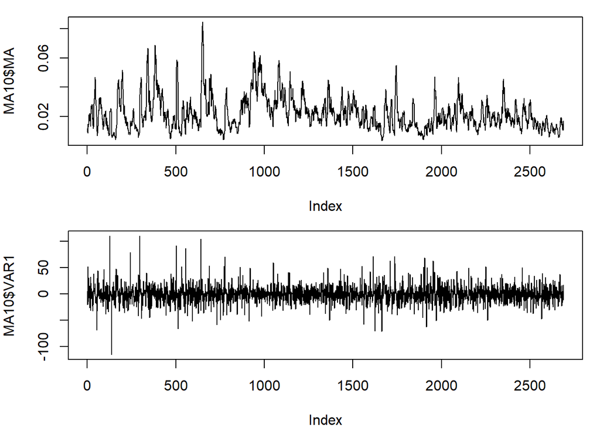

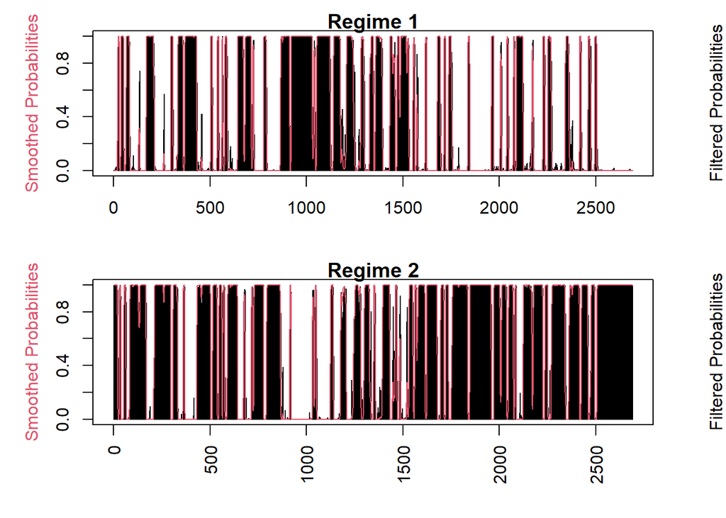

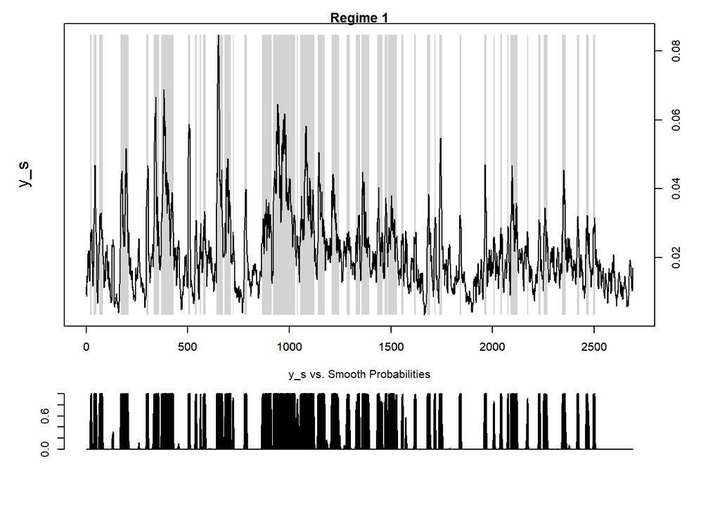

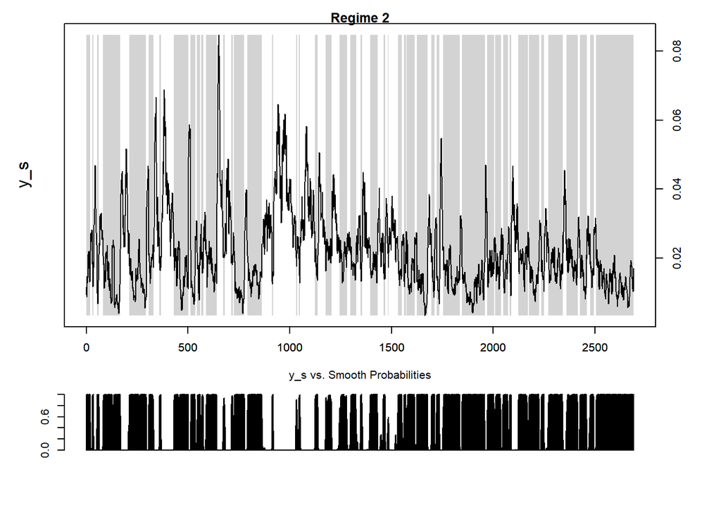

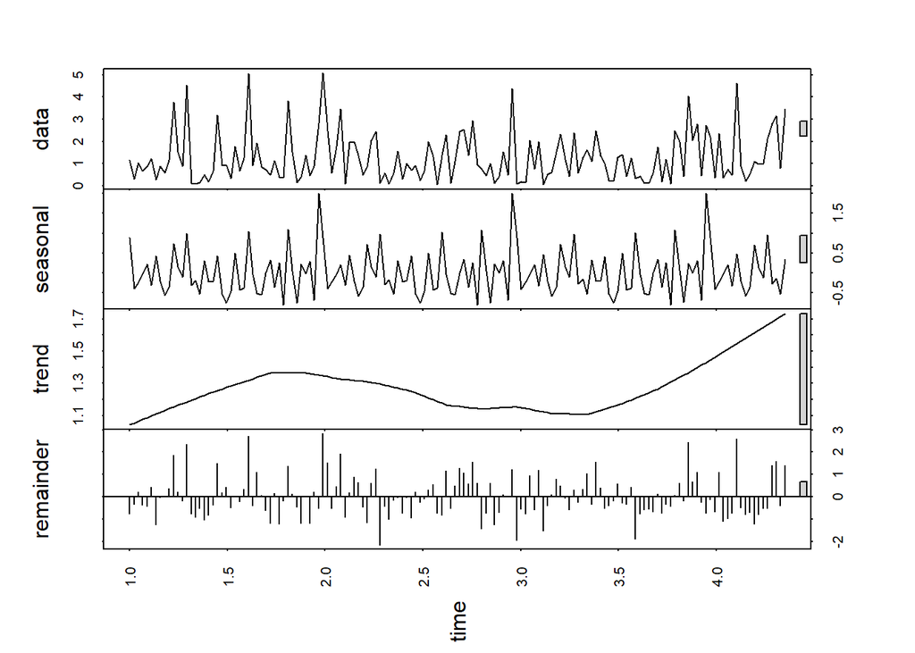

```
## Time Series:
## Start = 4.23911980440098
## End = 4.35158924205379
## Frequency = 44.4565217391304
##            seasonal    trend  remainder
## 4.239120 -0.1158889 1.645603 -0.5268923
## 4.261614  0.9560811 1.663136 -0.5059828
## 4.284108 -0.2699711 1.680669  1.4084407
## 4.306601 -0.1436994 1.698202  1.5829667
## 4.329095 -0.5281429 1.715735 -0.3877406
## 4.351589  0.3389255 1.733267  1.3918289
```

```
##          Point Forecast      Lo 80    Hi 80      Lo 95    Hi 95
## 4.374083      1.5956108  0.3633240 2.827898 -0.2890093 3.480231
## 4.396577      1.0571034 -0.1751834 2.289390 -0.8275167 2.941723
## 4.419071      1.0720212 -0.1602656 2.304308 -0.8125989 2.956641
## 4.441565      1.6821669  0.4498800 2.914454 -0.2024532 3.566787
## 4.464059      0.7358099 -0.4964770 1.968097 -1.1488102 2.620430
```

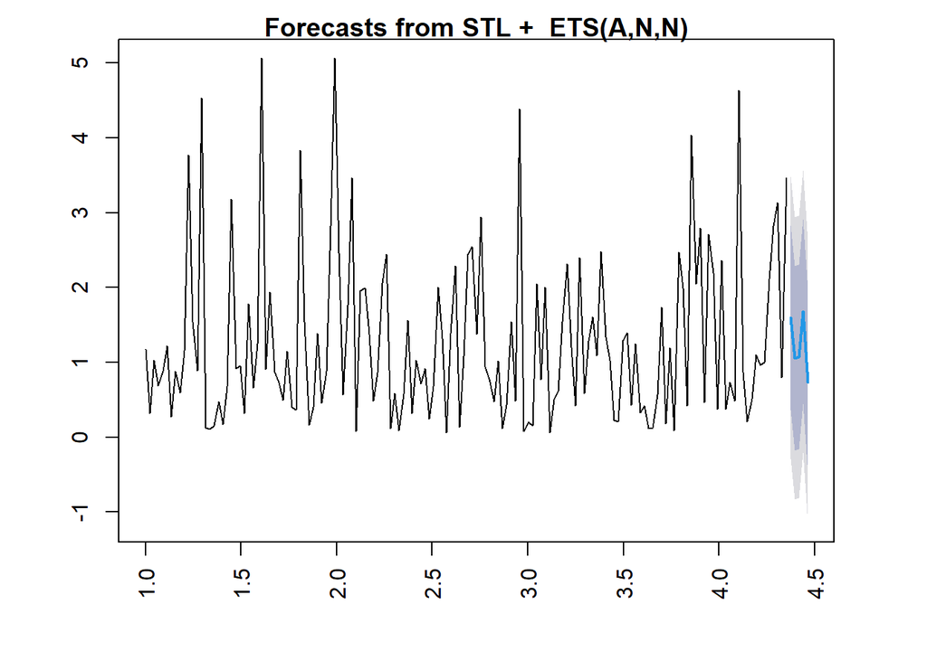

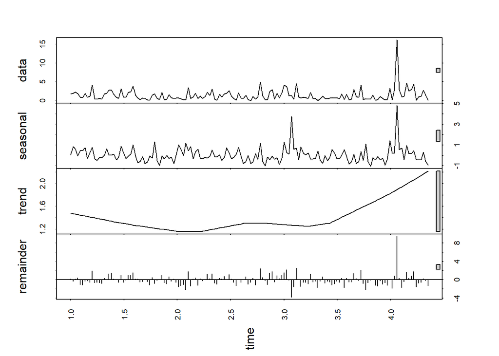

```
## Time Series:
## Start = 4.23911980440098
## End = 4.35158924205379
## Frequency = 44.4565217391304
##            seasonal    trend  remainder
## 4.239120 -0.4534608 2.089567 -1.5332420
## 4.261614 -0.4427321 2.115750 -0.6638843
## 4.284108 -0.4606198 2.141933 -0.5397279
## 4.306601  0.3112972 2.168116  0.2875387
## 4.329095 -0.5741106 2.194299 -0.1141820
## 4.351589 -0.9327256 2.220482 -1.2250520
```

```
##          Point Forecast       Lo 80    Hi 80      Lo 95    Hi 95
## 4.374083      0.9456921 -0.73543689 2.626821 -1.6253728 3.516757
## 4.396577      1.7049221  0.02278903 3.387055 -0.8676784 4.277523
## 4.419071      1.1987156 -0.48442084 2.881852 -1.3754195 3.772851
## 4.441565      1.5104953 -0.17364398 3.194635 -1.0651735 4.086164
## 4.464059      2.2818176  0.59667610 3.966959 -0.2953839 4.859019
```

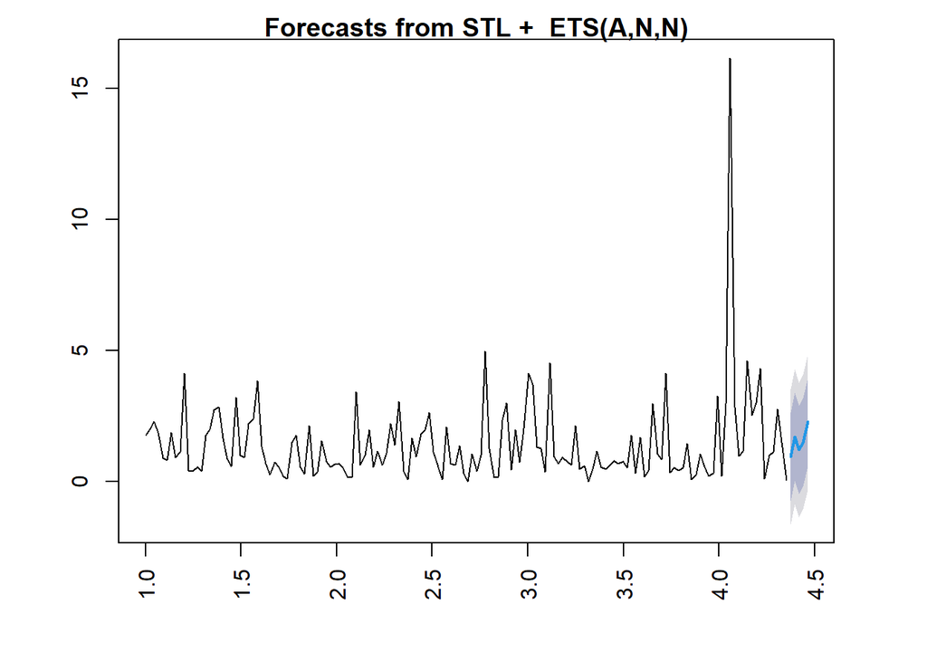